# Results for Peer Assessment 1: Step Monitoring Data

First we load the data, it’s a csv file so no need to worry about options. Then munge the date column to be an R Date object.

```r
Adata <- read.csv("activity.csv")
Adata$date <- as.Date(Adata$date, "%Y-%m-%d")
```

Get rid of the NA. Makes finding mean and median a litle cleaner.

```r
useData <- subset(Adata, !is.na(steps))
```

Create a histogram of the total number of steps taken each day. First we need at aggregate over all intervals.

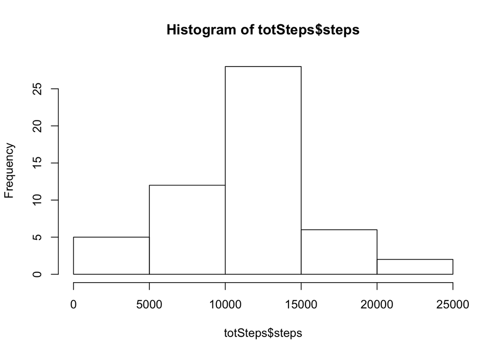

```r
totSteps <- aggregate(steps ~ date, data=useData, FUN="sum")
hist(totSteps$steps)
```

Find the mean and median of the total number of steps per day.

```r
mean(totSteps$steps)
```

```
## [1] 10766
```

```r
median(totSteps$steps)
```

```
## [1] 10765
```

Aggregate to find the average number of steps per interval over all days. Then do the plot.

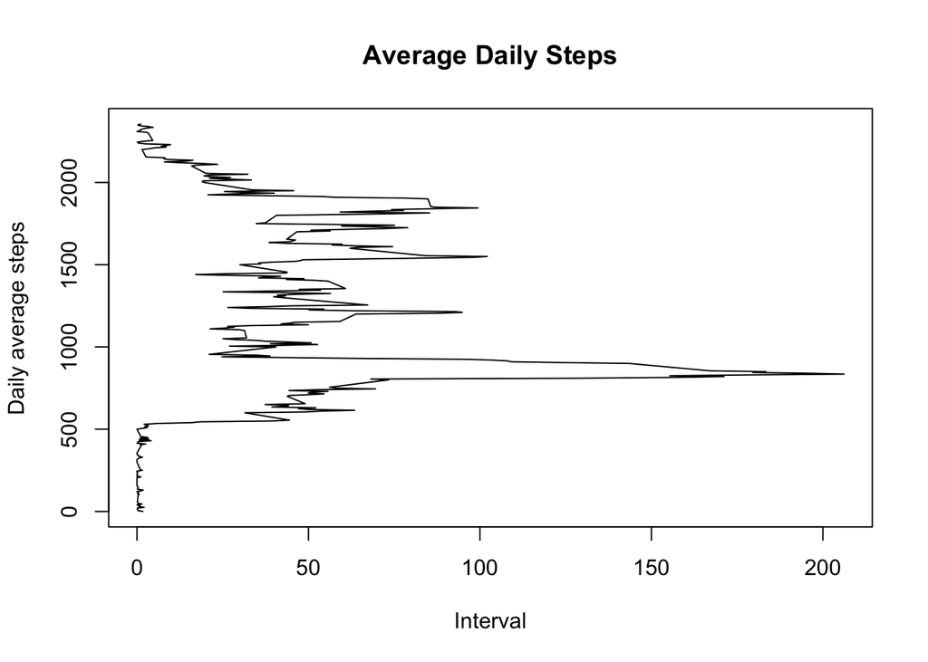

```r
avgedStepsByInterval <- aggregate(steps ~ interval,data=useData, FUN="mean")
with(avgedStepsByInterval, plot(steps, interval, type="l", xlab="Interval", ylab="Daily average steps", main="Average Daily Steps"))
```

Now we want to find the interval that has the highest average number of steps. First find that maximum and then the row that contains that value.

```r
mSteps <- max(avgedStepsByInterval$steps)
subset(avgedStepsByInterval, steps==mSteps)
```

```
##     interval steps
## 104      835 206.2
```

Calculate and report the total number of missing values in the dataset

```r
nrow(subset(Adata, is.na(steps)))
```

```
## [1] 2304
```

Aggregate to find the average number of steps for each day. This is used later to fill in missing data.

```r
avgedSteps <- aggregate(steps ~ date,data=useData, FUN="mean")
```

Now we want to replace missing data. This is a little slow.

```r
start <- TRUE
for (i in 1:nrow(Adata)) {
     ii <- Adata[i,]
     if (is.na(ii[1,1])) {
         sst <- avgedSteps[avgedSteps$date == ii[1,2], 2]
         if (length(sst)>0) {
             rii <- list(steps=avgedSteps[avgedSteps$date == ii[1,2], 2], date=ii[1,2], interval=ii[1,3])
         } else {
             rii <- list(steps=0, date=ii[1,2], interval=ii[1,3])
         }
     } else {
         rii <- ii
     }
     if (start==TRUE) {
         store1 <- data.frame(rii)
         names(store1) <- names(Adata)
         start <- FALSE
     } else {
         store1 <- rbind(store1, rii)
     }
}
```

New mean and median, just to see what happened.

```r
mean(store1$steps)
```

```
## [1] 32.48
```

```r
median(store1$steps)
```

```
## [1] 0
```

Then the new histogram of the modified data, along with the new mean and median.

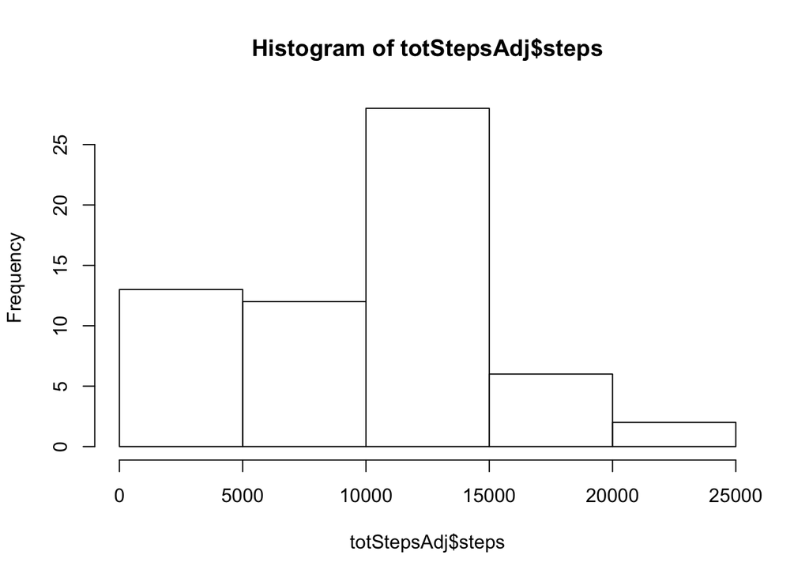

```r
totStepsAdj <- aggregate(steps ~ date, data=store1, FUN="sum")
hist(totStepsAdj$steps)
```

```r
mean(totStepsAdj$steps)
```

```
## [1] 9354
```

```r
median(totStepsAdj$steps)
```

```
## [1] 10395
```

Creating factor of weekdays and weekends and storing it. This function is applied to the date to decied if it is a week day or weekend day.

```r
gg <- function(aDay) {
    if (weekdays(aDay) %in% c("Monday", "Tuesday", "Wednesday", "Thursday", "Friday")) {
        "weekday"
    } else {
        "weekend"
    }
}
tts <- sapply(store1$date, FUN=gg)
ttsf <- factor(tts)
store1$ext <- ttsf
```

Now two plots, average step counts for each interval over all days.

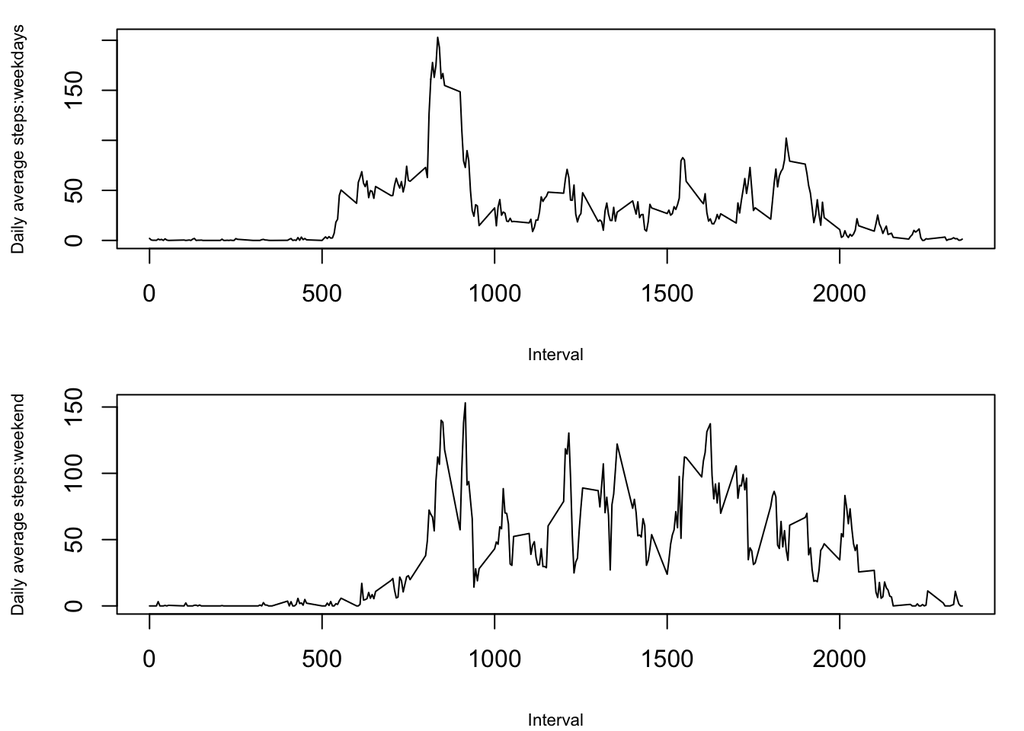

```r
par(mfrow=c(2,1), pin=c(5,3), mar=c(4,4,1,1))
with(aggregate(steps ~ interval, data=subset(store1, ext=="weekday",xlab="Interval", ylab="Daily average steps"), FUN="mean"), plot(interval, steps, type="l",xlab="Interval", ylab="Daily average steps:weekdays", cex.lab=0.7))
with(aggregate(steps ~ interval, data=subset(store1, ext=="weekend"), FUN="mean"), plot(interval, steps, type="l",xlab="Interval", ylab="Daily average steps:weekend", cex.lab=0.7))
```